# THE IMPACT OF PHYSICAL ACTIVITY ON STUDENTS’ ACADEMIC PERFORMANCE AND STRESS LEVELS

Author

Hafsa Altaf, Hoang Son Lai, Xingyu Wang

## Executive summary

This report investigates the relationship between physical activity, academic performance (GPA), and stress levels among 2,000 students. Physical activity duration was categorized into four groups to examine patterns and trade-offs. The analysis finds that students engaging in higher levels of daily physical activity tend to report lower stress but also slightly lower GPA. These findings support promoting balanced physical activity to enhance well-being without compromising academic success.

## Introduction

Student well-being is increasingly recognized as a key component of academic success and overall academic experience. Physical activity is widely acknowledged to reduce stress, yet its relationship with academic performance remains less clear. This report addresses the question: **How does the amount of daily physical activity relate to students’ GPA and perceived stress levels?**

The data analyzed comes from a Google Form survey completed by 2,000 students, capturing self-reported lifestyle habits, GPA, and stress levels. Students were categorized by their average daily exercise duration, as described in Methodology section (Section 3). And the Results section (Section 4) presents the observed trends.

The aim of this report is to assess whether more physically active students experience better mental well-being and how this may relate to academic performance. Understanding these patterns can help inform strategies for promoting a balanced and productive student lifestyle.

## Methodology

The [data set](https://www.kaggle.com/datasets/steve1215rogg/student-lifestyle-dataset) consists of responses from 2,000 students collected through a standardized questionnaire. It includes data on self-reported academic performance (GPA), stress levels, and various lifestyle habits. In this report, we focus on three key variables:

- Grade point average (GPA), which reflects students’ academic performance on a 4.0 scale.
- Stress levels, categorized as Low, Moderate, or High.
- Daily physical activity duration, measured in hours.

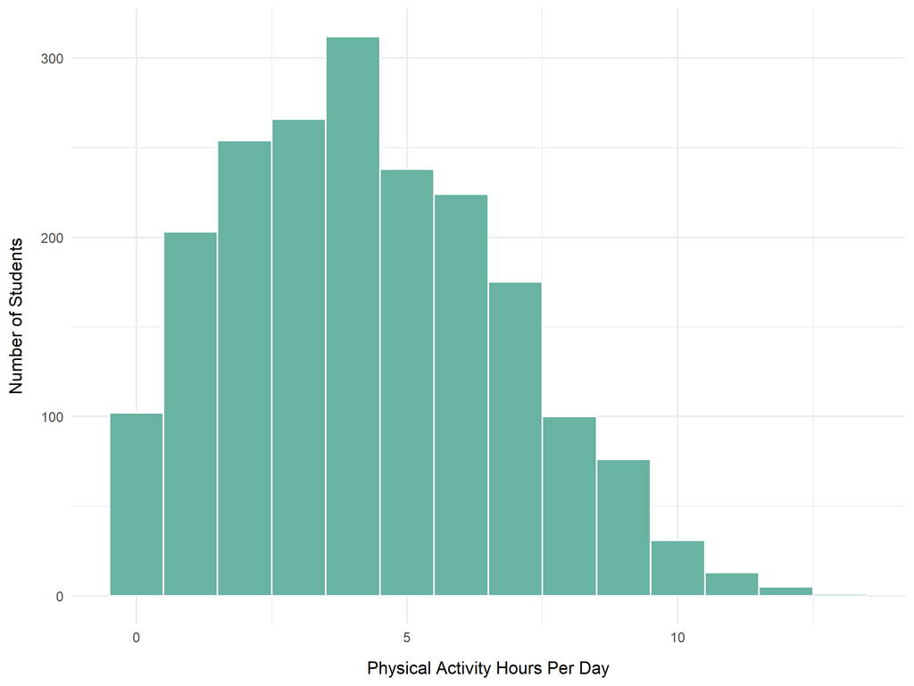

Figure 1: Distribution of physical activity hours per day

Figure 1 presents the distribution of physical activity hours per day among participants. The data show a unimodal and right-skewed pattern, indicating that most students engage in moderate physical activity. The majority report engaging in physical activity for 2 to 6 hours daily, with a notable concentration between 3 and 5 hours. Very few students report extremely high activity levels (above 8 hours). Based on this distribution, physical activity duration was grouped into four categories to facilitate comparison:

- Under 2 hours
- 2-3 hours
- 4-5 hours
- More than 6 hours

This grouping aims to balance sample size across categories while maintaining behavioral and health-related distinctions.

The summary statistics for each group are presented in Table 1. Stress levels were numerically encoded for analysis purposes: Low = 1, Moderate = 2, High = 3, such that a lower mean value represents lower average stress.

Table 1: Summary of GPA and stress level by physical activity group

| Physical activity group | Number of students | Average GPA | Average stress level |
| --- | --- | --- | --- |
| Under 2 hours | 394 | 3.26 | 2.64 |
| 2 - 3 hours | 550 | 3.17 | 2.45 |
| 4 - 5 hours | 526 | 3.09 | 2.25 |
| More than 6 hours | 530 | 2.98 | 2.19 |

The results show a gradual decrease in both GPA and perceived stress levels with increasing physical activity. Students in the under-2-hour group report the highest GPA but also the highest stress levels. Conversely, those in the more-than-6-hour group have the lowest GPA and the lowest stress levels.

These patterns provide the foundation for further analysis in the Results section, where the impact of physical activity on academic performance and stress levels is examined using visualizations such as a jitter plot and a stacked bar chart.

## Results

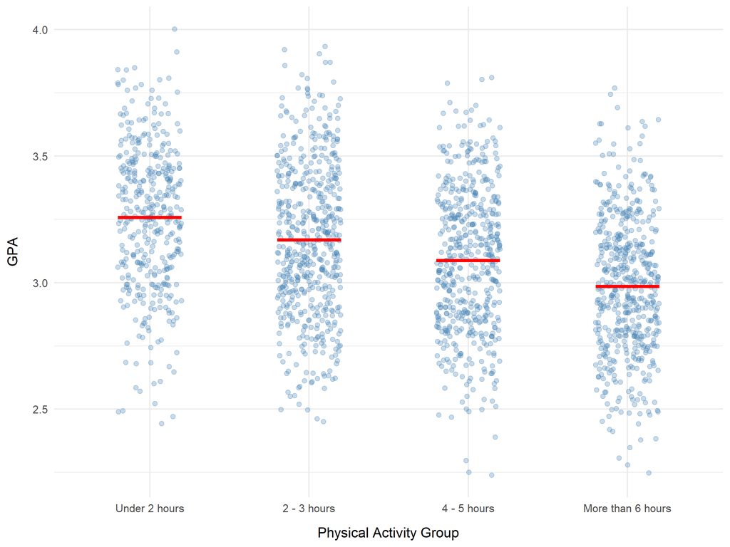

Figure 2: GPA distribution by physical activity group

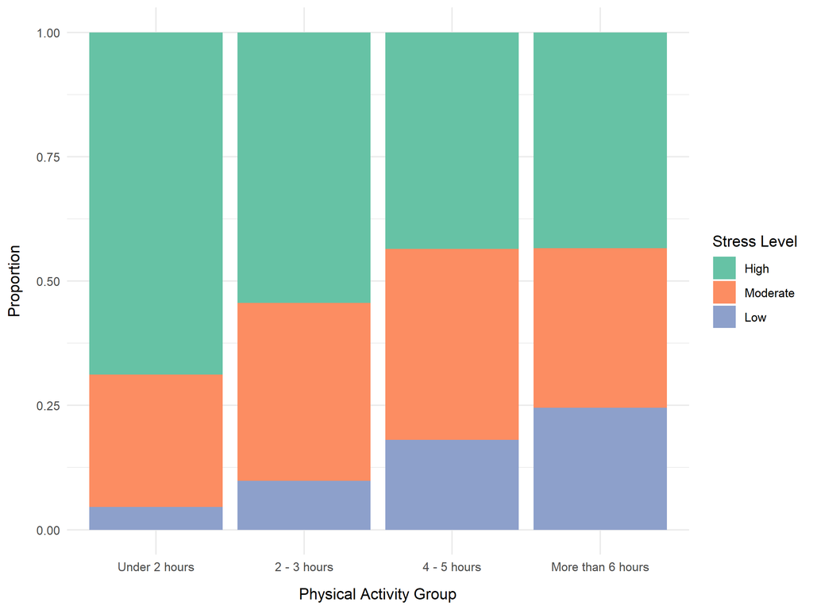

Figure 3: Stress level distribution by physical activity group

Figure 2 illustrates the distribution of GPA across four groups defined by daily physical activity duration. While individual GPA scores vary within each group, the red crossbars indicate that the mean GPA slightly decreases as physical activity increases. Students engaging in less than 2 hours of daily physical activity tend to have the highest average GPA, whereas those reporting more than 6 hours of activity per day exhibit the lowest average GPA. This pattern suggests a modest negative association between physical activity duration and academic performance.

Figure 3 presents the distribution of self-reported stress levels within each physical activity group. Students with under 2 hours of physical activity show the highest proportion of high stress. As physical activity increases, the share of students reporting high stress declines, while the proportions of moderate and low stress rise - most notably in the 4 - 5 hours and more than 6 hours groups. The most active students report the lowest levels of high stress and the highest levels of low stress.

Taken together, the two figures highlight a potential trade-off: increased physical activity appears to be associated with lower stress levels, but also with a slightly lower GPA.

## Discussion

The findings highlight a nuanced relationship between physical activity, academic performance, and stress among students. While increased physical activity appears to reduce perceived stress levels, as shown in Figure 3, it may also be associated with a marginal decline in GPA (Figure 2). These opposing trends reflect a possible trade-off between mental well-being and academic output.

Several factors may contribute to this pattern. Students engaging in more physical activity may prioritize health and social balance over academic intensity, potentially reducing time or energy devoted to study. Conversely, those with limited physical activity may be more academically driven but face higher stress, possibly due to reduced outlets for relaxation or physical release.

It is important to note that these associations do not imply causation. Self-reported measures of both GPA and stress may be subject to bias, and unmeasured confounders - such as sleep quality, part-time work, or social support - could influence the observed trends. Moreover, the decline in GPA across groups is modest and should not be overstated.

Ultimately, these findings suggest that encouraging moderate physical activity may enhance student well-being without severely compromising academic outcomes. Future research could explore optimal activity ranges or the role of time management in balancing study and health.

## Conclusion and recommendations

This report explored the relationship between physical activity, GPA, and stress levels among students. As discussed earlier, students who engage in more daily physical activity tend to experience lower stress but may also report slightly lower academic performance (see Section 5). These trends suggest a potential trade-off between well-being and academic outcomes.

To support student health without compromising learning, institutions should encourage balanced routines. Specifically, we recommend:

- Promoting moderate physical activity (from 2 to 5 hours per day) as part of student wellness programs.
- Offering time management workshops to help students integrate study and exercise effectively.
- Investigating additional factors such as sleep, nutrition, and academic workload to gain a more holistic understanding of student performance.

## Reference

American College Health Association. (2020). *National College Health Assessment III: Spring 2020 reference group executive summary*. https://portal.acha.org/documents/ncha/NCHA-III_SPRING-2020_REFERENCE_GROUP_EXECUTIVE_SUMMARY.pdf

El Ansari, W., & Stock, C. (2010). Is the health and wellbeing of university students associated with their academic performance? Cross-sectional findings from the United Kingdom. *International Journal of Environmental Research and Public Health, 7(2)*, 509–527. https://doi.org/10.3390/ijerph7020509

Kumar, S. (n.d.). *Student lifestyle dataset*. Kaggle. https://www.kaggle.com/datasets/steve1215rogg/student-lifestyle-dataset

Pascoe, M. C., Hetrick, S. E., & Parker, A. G. (2020). The impact of stress on students in secondary school and higher education. *International Journal of Adolescence and Youth, 25(1)*, 104–112. https://doi.org/10.1080/02673843.2019.1596823